# Practica 2

```python
import numpy as np
import pandas as pd
import seaborn as sns
import matplotlib.pyplot as plt
import statsmodels.api as sm
from statsmodels.formula.api import ols
from statsmodels.stats.outliers_influence import variance_inflation_factor
from sklearn.ensemble import ExtraTreesClassifier

%config Completer.use_jedi = False
%matplotlib inline
```

## 1 Descripció del Dataset

Aquest dataset es tracta d'un conjunt de pacients en el qual se'ls hi recull un seguit de dades mèdiques i físiològiques com per exemple edat, sexe, pulsacions màximes etc... i se'ls classifica segons si la probabilitat de tenir un atac de cor és alta (1) o simplement és baixa (0). Aquestes dades son importants per tal de realitzar un algoritme predictiu tal que extretes unes dades del pacient, se'l pugui classificar com a pacient amb risc d'atac de cor (i realitzar les accions oportunes abans que aquest passi) o com a pacient amb un baix risc.

## 2 Integració i selecció

En descarregar les dades del kaggle recomanat per la pràctica, s'observa que hi han dos datasets diferents. Un amb totes 303 linies on hi ha 14 variables diferents, i un altre on hi ha la saturació d'oxigen amb 3585 linies i 1 variable. La idea principal era integrar aquests dos datasets per tal de formar-ne un de conjunt. No obstant, el dataset de saturació no hi ha cap clau primaria que es pugui relaciónar amb el dataset principal. És per això que finalment no integraré els dos conjunts ja que podria fer associacions falses entre saturació de O2 i les dades de cada pacient.

```python
# Pujada del arxiu amb les dades del heart
inicial = pd.read_csv("C:/Users/ricar/OneDrive/Escritorio/Màster Data Science UOC/Assignatures/Assignatures master/Tipologia i cicle de vida de les dades/Pràctica 2/heart.csv")
print(inicial.shape)
inicial.head()
```

```
(303, 14)
```

|  | age | sex | cp | trtbps | chol | fbs | restecg | thalachh | exng | oldpeak | slp | caa | thall | output |
| --- | --- | --- | --- | --- | --- | --- | --- | --- | --- | --- | --- | --- | --- | --- |
| 0 | 63 | 1 | 3 | 145 | 233 | 1 | 0 | 150 | 0 | 2.3 | 0 | 0 | 1 | 1 |
| 1 | 37 | 1 | 2 | 130 | 250 | 0 | 1 | 187 | 0 | 3.5 | 0 | 0 | 2 | 1 |
| 2 | 41 | 0 | 1 | 130 | 204 | 0 | 0 | 172 | 0 | 1.4 | 2 | 0 | 2 | 1 |
| 3 | 56 | 1 | 1 | 120 | 236 | 0 | 1 | 178 | 0 | 0.8 | 2 | 0 | 2 | 1 |
| 4 | 57 | 0 | 0 | 120 | 354 | 0 | 1 | 163 | 1 | 0.6 | 2 | 0 | 2 | 1 |

```python
# Pujada de l'arxiu amb les dades de la saturació de 02

saturacio = pd.read_csv("C:/Users/ricar/OneDrive/Escritorio/Màster Data Science UOC/Assignatures/Assignatures master/Tipologia i cicle de vida de les dades/Pràctica 2/o2Saturation.csv")
print(saturacio.shape)
saturacio.head()
```

```
(3585, 1)
```

|  | 98.6 |
| --- | --- |
| 0 | 98.6 |
| 1 | 98.6 |
| 2 | 98.6 |
| 3 | 98.1 |
| 4 | 97.5 |

Per tal d'analitzar possibles relacions (tant lineals com no lineals) entre variables i poder descartar aquelles que ens aporten informació redundant, es realitza una matriu de scatterplots amb totes les variables distingides per si tenen probabilitat altes d'atac de cor o no.

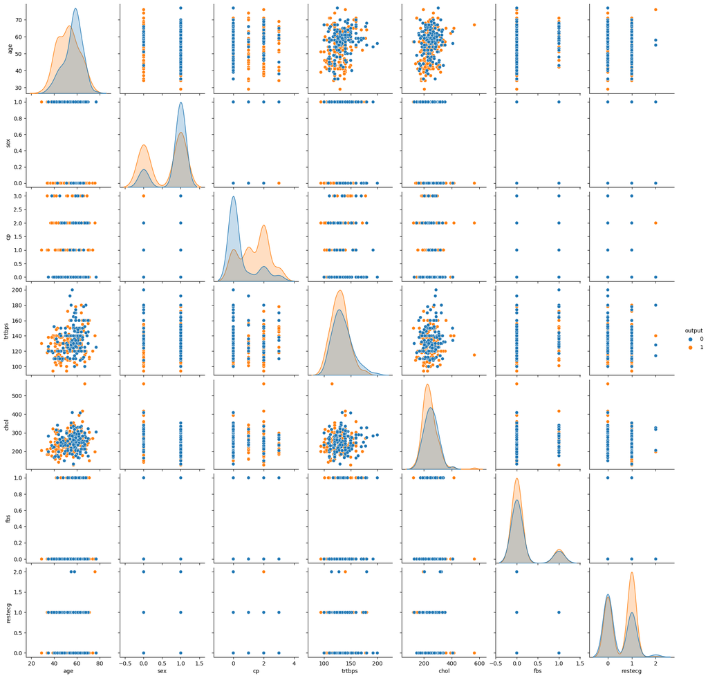

```python
sub1 = inicial.iloc[:,[0,1,2,3,4,5,6,13]]
sns.pairplot(sub1,hue="output")
# plt.show()
```

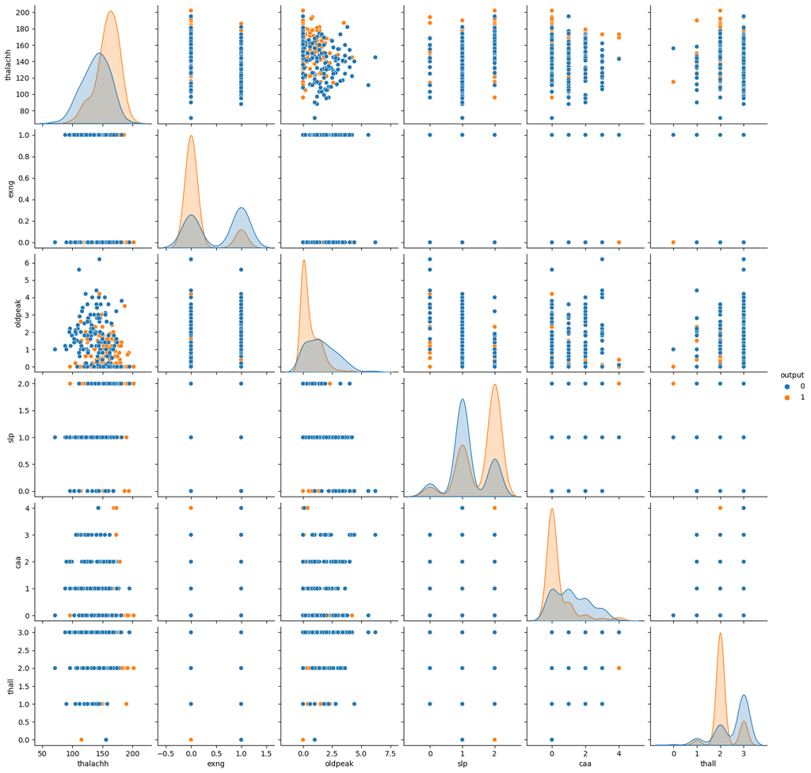

```python
sns.pairplot(inicial.iloc[:,[7,8,9,10,11,12,13]],hue="output")
```

Aquest primer gràfic no ens permet veure conclusions molt rellevants per lo que s'hauria de mirar amb més detall. Fent un heatmap de correlació de variables tenim (només agafem les numèriques):

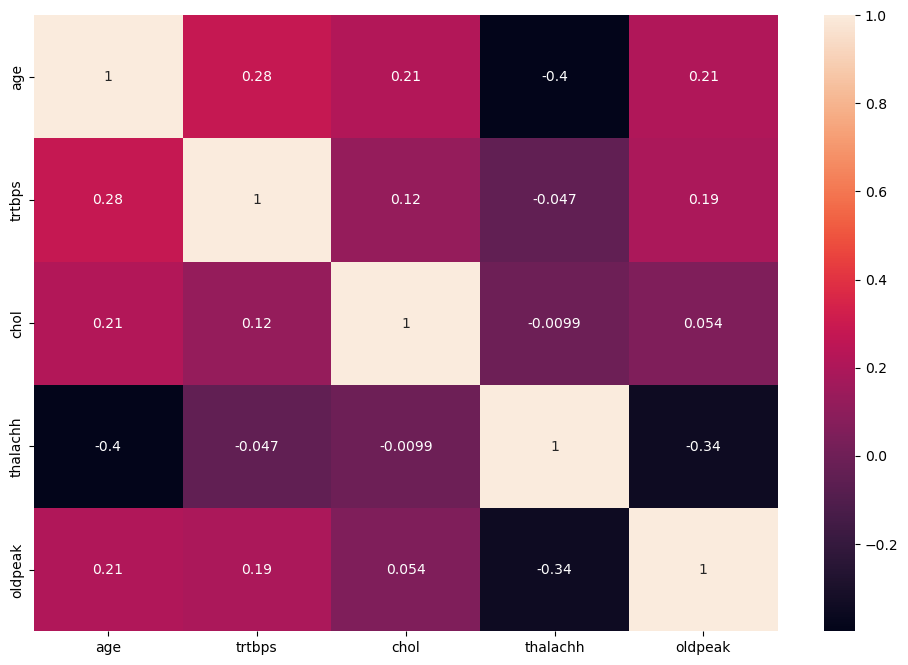

```python
numeriques = inicial.drop(columns=["sex","exng","caa","cp","fbs","restecg","output","slp","thall"])

fig = plt.figure(figsize=(12,8))
sns.heatmap(numeriques.corr(),annot=True)
```

D'aquest heatmap s'extreuen les següents conclusions: hi ha una relació negativa entre les pulsacions màximes i 'edat, i també hi ha certa relació entre les màximes pulsacions i l'oldpeak, tot i així son correlacions "mitjanes".

A priori, abans de treure els outliers no es descarta cap variable ja que ho farem en apartats posteriors on seleccioanrem les dades més significatives.

## 3 Neteja de les dades

### 3.1. Les dades contenen zeros o elements buits? Gestiona cadascun d’aquests casos.

Cap dada conte valors nuls. En cas de contindre, faríem imputació de valors nulls per KNN per exemple

```python
inicial.isna().sum()
```

```
age         0
sex         0
cp          0
trtbps      0
chol        0
fbs         0
restecg     0
thalachh    0
exng        0
oldpeak     0
slp         0
caa         0
thall       0
output      0
dtype: int64
```

### 3.2. Identifica i gestiona els valors extrems.

```
(303, 5)
```

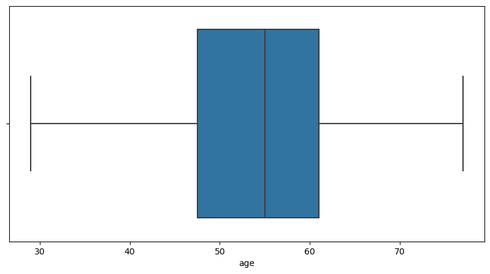

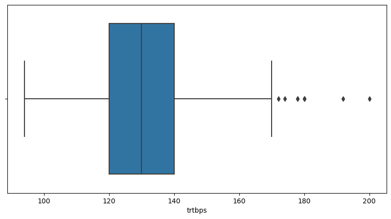

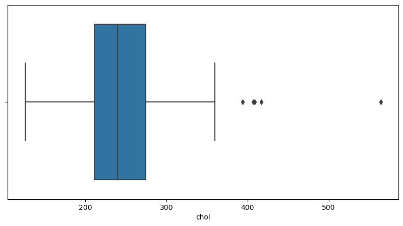

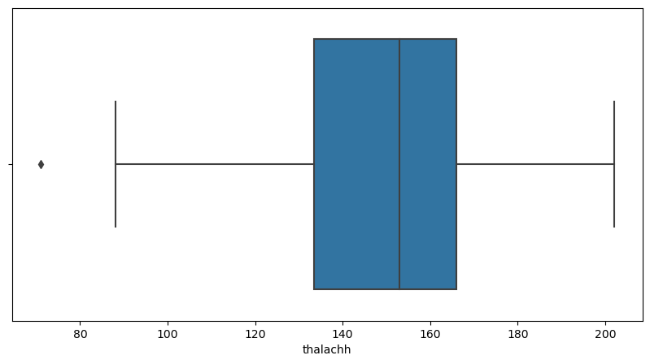

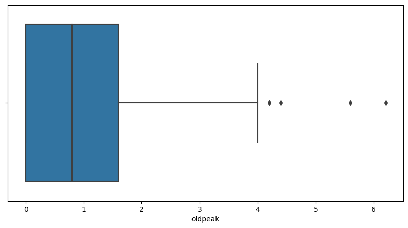

```python
display(numeriques.shape)
for feature in numeriques.columns:
    plt.figure(figsize=(10,5))
    sns.boxplot(x=numeriques[feature])
    plt.show()
```

Després de fer certes cerques, els valors que ens surten com a outliers en aquests boxplots, no es podria assegurar que ho fossin, ja que son valors poc comuns però tot i així s'han de tindre en compte perque son possibles i indicadors de malalties cardíaques.

### 4 Anàlisis de les dades

Primerament, es fa un anàlisis de les nostres variables amb algunes mesures de tendència central i disperció, d'aquesta manera també podem veure valors extrems en el min i max si s'allunya molt de la mitjana o dels quartils.

```python
d=pd.concat([inicial.describe(),inicial.agg(["skew","mad","kurt","median"])])
d
```

|  | age | sex | cp | trtbps | chol | fbs | restecg | thalachh | exng | oldpeak | slp | caa | thall | output |
| --- | --- | --- | --- | --- | --- | --- | --- | --- | --- | --- | --- | --- | --- | --- |
| count | 303.000000 | 303.000000 | 303.000000 | 303.000000 | 303.000000 | 303.000000 | 303.000000 | 303.000000 | 303.000000 | 303.000000 | 303.000000 | 303.000000 | 303.000000 | 303.000000 |
| mean | 54.366337 | 0.683168 | 0.966997 | 131.623762 | 246.264026 | 0.148515 | 0.528053 | 149.646865 | 0.326733 | 1.039604 | 1.399340 | 0.729373 | 2.313531 | 0.544554 |
| std | 9.082101 | 0.466011 | 1.032052 | 17.538143 | 51.830751 | 0.356198 | 0.525860 | 22.905161 | 0.469794 | 1.161075 | 0.616226 | 1.022606 | 0.612277 | 0.498835 |
| min | 29.000000 | 0.000000 | 0.000000 | 94.000000 | 126.000000 | 0.000000 | 0.000000 | 71.000000 | 0.000000 | 0.000000 | 0.000000 | 0.000000 | 0.000000 | 0.000000 |
| 25% | 47.500000 | 0.000000 | 0.000000 | 120.000000 | 211.000000 | 0.000000 | 0.000000 | 133.500000 | 0.000000 | 0.000000 | 1.000000 | 0.000000 | 2.000000 | 0.000000 |
| ... | ... | ... | ... | ... | ... | ... | ... | ... | ... | ... | ... | ... | ... | ... |
| max | 77.000000 | 1.000000 | 3.000000 | 200.000000 | 564.000000 | 1.000000 | 2.000000 | 202.000000 | 1.000000 | 6.200000 | 2.000000 | 4.000000 | 3.000000 | 1.000000 |
| skew | -0.202463 | -0.791335 | 0.484732 | 0.713768 | 1.143401 | 1.986652 | 0.162522 | -0.537410 | 0.742532 | 1.269720 | -0.508316 | 1.310422 | -0.476722 | -0.179821 |
| mad | 7.457112 | 0.432899 | 0.912743 | 13.522530 | 39.314141 | 0.252916 | 0.512368 | 18.484397 | 0.439957 | 0.929562 | 0.562995 | 0.842510 | 0.530144 | 0.496030 |
| kurt | -0.542167 | -1.382961 | -1.193071 | 0.929054 | 4.505423 | 1.959678 | -1.362673 | -0.061970 | -1.458317 | 1.575813 | -0.627521 | 0.839253 | 0.297915 | -1.980783 |
| median | 55.000000 | 1.000000 | 1.000000 | 130.000000 | 240.000000 | 0.000000 | 1.000000 | 153.000000 | 0.000000 | 0.800000 | 1.000000 | 0.000000 | 2.000000 | 1.000000 |

Com es pot veure, totes segueixen més o menys normalitat (Excepte oldpeak). Tot i així les cues de les distribución o estan sesgades, o els valors "outliers" les fan desviar.

A partir d'aquí, es procedeix a fer una selecció de variables utilitzant un model logístic, on a través de tests de contrast d'hipòtesis per saber si la variable és significativa en relació a l'output i testos de colinealitat entre variables, es determinarà quines son les variables més adequades.

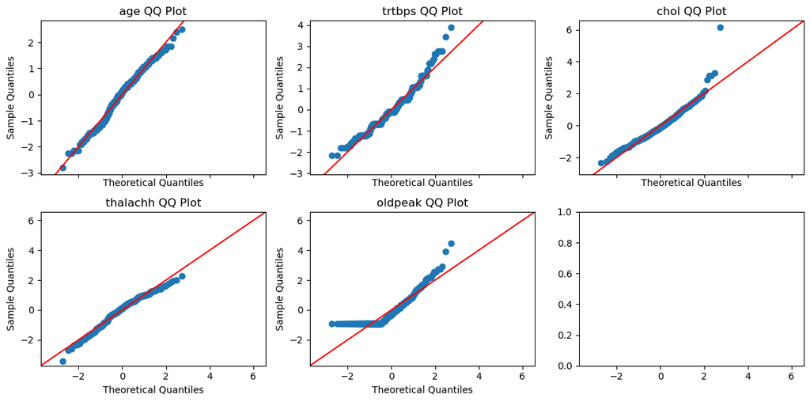

```python
fig, axes = plt.subplots(ncols=3, nrows=2, sharex=True, figsize=(4*3, 2*3))
for k, ax in zip(numeriques.columns, np.ravel(axes)):
    sm.qqplot(numeriques[k], line='45',fit = True, ax=ax)
    ax.set_title(f'{k} QQ Plot')
plt.tight_layout()
```

Iteració 1 (es decarta trtbps):

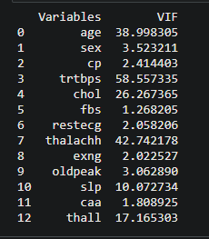

Iteració 2 (es descarta thalachh):

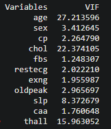

Iteració 3 (es descarta age):

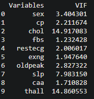

Iteració 4 (es descarta chol):

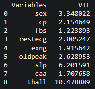

Iteració 5 (es descarta thall):

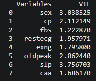

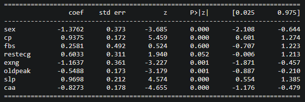

```python
# es separen les variables target (output) i la resta de variables independents
y=inicial.output
X = inicial.iloc[:,:-1]
X.drop(columns=["trtbps","thalachh","age","chol","thall","fbs","restecg"],inplace=True)
#fem un fit del model i veiem els resultats

logit_model=sm.Logit(y,X)
result=logit_model.fit()
print(result.summary())
```

```
Optimization terminated successfully.
         Current function value: 0.394730
         Iterations 7
                           Logit Regression Results
==============================================================================
Dep. Variable:                 output   No. Observations:                  303
Model:                          Logit   Df Residuals:                      297
Method:                           MLE   Df Model:                            5
Date:                Sun, 08 Jan 2023   Pseudo R-squ.:                  0.4272
Time:                        13:06:10   Log-Likelihood:                -119.60
converged:                       True   LL-Null:                       -208.82
Covariance Type:            nonrobust   LLR p-value:                 1.157e-36
==============================================================================
                 coef    std err          z      P>|z|      [0.025      0.975]
------------------------------------------------------------------------------
sex           -1.3276      0.370     -3.590      0.000      -2.052      -0.603
cp             0.9541      0.167      5.699      0.000       0.626       1.282
exng          -1.0747      0.353     -3.042      0.002      -1.767      -0.382
oldpeak       -0.4905      0.167     -2.934      0.003      -0.818      -0.163
slp            1.1034      0.199      5.543      0.000       0.713       1.494
caa           -0.8004      0.174     -4.587      0.000      -1.142      -0.458
==============================================================================
```

```python
#colinealitat

VIF_modelg = pd.DataFrame()
VIF_modelg["Variables"] = X.columns

#Es calculen els VIF per a les variables:

VIF_modelg['VIF'] = [variance_inflation_factor(X, i) for i in range(X.shape[1])]
print(VIF_modelg.to_string())
```

```
  Variables       VIF
0       sex  3.028078
1        cp  2.030867
2      exng  1.781966
3   oldpeak  2.007561
4       slp  3.191513
5       caa  1.637583
```

Finalment el grup de variables que s'han seleccionat són:

- sex
- cp
- exng
- oldpeak
- slp
- caa

Per a comprovar amb un altre mètode quines son les variables que prenen més importancia a l'hora de predir l'output, s'utilitza un ExtraTreesClassifier de sklearn per treure els "feature*importances*".

En aquest cas, si treguéssim les variables que amb un anàlisi de colinealitat ens donarien com a que son colineals, obtindríem el mateix resultat que en l'anterior mètode. Tot i així, els arbres de decisió no estan afectats per la colinealitat per tant, si féssim una predicció a través d'un mètode d'aquest tipus, es podrien seleccionar les següents variables (en cas de agafar-ne 6)

- caa
- cp
- exng
- thall
- oldpeak
- thalachh

```python
X = inicial.iloc[:,:-1]
variables = X.columns
# s'extreuen les variables per importancia
model = ExtraTreesClassifier(n_estimators=100)
model.fit(X,y)
print(sorted(list(zip(variables,model.feature_importances_)),key= lambda x:x[1],reverse=True))
```

[output not shown]